# Group project assessment

Exam Numbers: B247222, B218357, B249236

2026-02-02

## Task 1: Reproducing and improving figures

```r
# load packages needed for all figures
library(tidyverse)
library(janitor)
library(here)
library(ggrepel)
library(grid)

# Path to the dataset
data_path <- here("data", "HIIT-postpartum-depression.csv")

# Read the data
data_raw <- read_csv(data_path, na = c("", "NA", "#NULL!"),
                     show_col_types = FALSE) %>%
  clean_names()
```

### Figure 3

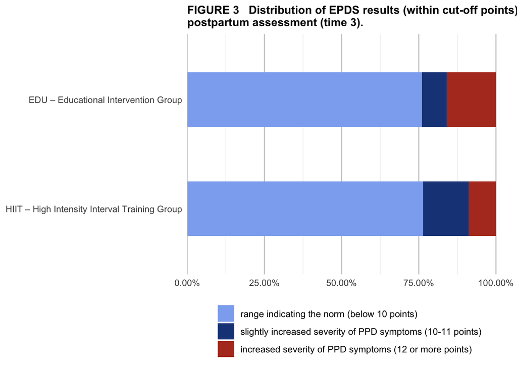

```r
# Write your code for reproducing, and then improving Figure 3. Present both figures together. Under the figures, explain how you've improved Figure 3 and why you consider this an improvement.

# PREPARE THE DATA FOR FIGURE 3
fig3_data <- data_raw %>%
  select(intervention_group, epds_score = edinburg_postnatal_depression_scale_score) %>%
  mutate(epds_score = as.numeric(epds_score)) %>%
  drop_na(epds_score) %>%

  mutate(category = case_when(
    epds_score < 10 ~ "range indicating the norm (below 10 points)",
    epds_score >= 10 & epds_score <= 11 ~ "slightly increased severity of PPD symptoms (10-11 points)",
    epds_score >= 12 ~ "increased severity of PPD symptoms (12 or more points)"
  )) %>%

  mutate(group_label = case_when(
    intervention_group == 1 ~ "HIIT – High Intensity Interval Training Group",
    intervention_group == 2 ~ "EDU – Educational Intervention Group"
  )) %>%

  group_by(group_label, category) %>%
  summarise(count = n(), .groups = "drop") %>%
  group_by(group_label) %>%
  mutate(percentage = count / sum(count) * 100) %>%

  # EDU TO TOP
  mutate(group_label = factor(group_label, levels = c(
    "HIIT – High Intensity Interval Training Group",
    "EDU – Educational Intervention Group"
  ))) %>%

  # LEGEND ORDER
  mutate(category = factor(category, levels = c(
    "increased severity of PPD symptoms (12 or more points)",
    "slightly increased severity of PPD symptoms (10-11 points)",
    "range indicating the norm (below 10 points)"
  )))

# PLOT FIGURE 3
plot_original <- ggplot(fig3_data, aes(x = group_label, y = percentage, fill = category)) +
  geom_col(width = 0.5) +
  coord_flip() +
  scale_fill_manual(values = c(
    "range indicating the norm (below 10 points)" = "#8daef0",
    "slightly increased severity of PPD symptoms (10-11 points)" = "#1d4487",
    "increased severity of PPD symptoms (12 or more points)" = "#b33925"
  )) +
  scale_y_continuous(labels = function(x) paste0(x, ".00%"),
                     expand = expansion(mult = c(0, 0.05))) +
  labs(
    title = "FIGURE 3   Distribution of EPDS results (within cut-off points) in the HIIT and EDU groups in the\npostpartum assessment (time 3).",
    x = NULL, y = NULL, fill = NULL
  ) +
  theme_minimal() +
  theme(
    legend.position = "bottom",
    legend.direction = "vertical",
    legend.justification = "center",
    panel.grid.major.y = element_blank(),
    panel.grid.major.x = element_line(color = "gray80"),
    plot.title = element_text(size = 11, face = "bold", hjust = 0),
    legend.text = element_text(size = 9)
  ) +
  guides(fill = guide_legend(reverse = TRUE))

plot_original
```

### Improved Figure 3

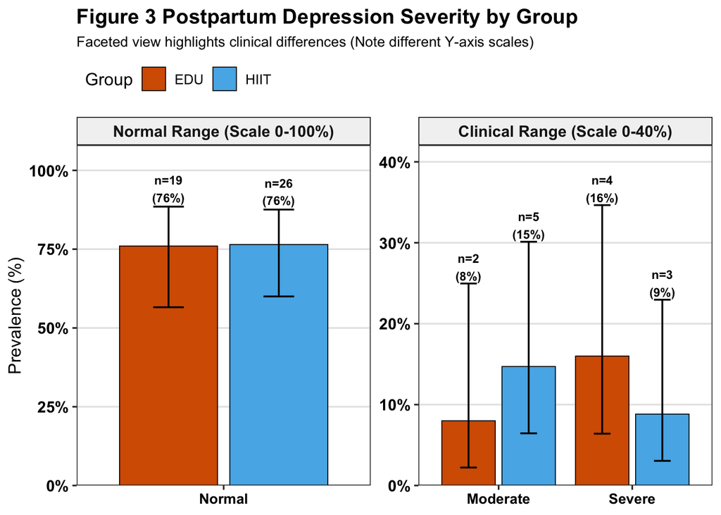

```r
# PREPARE DATA
fig3_faceted <- fig3_data %>%
  # Create short Group Names
  mutate(group_short = case_when(
    str_detect(group_label, "HIIT") ~ "HIIT",
    str_detect(group_label, "EDU") ~ "EDU"
  )) %>%
  # Create short Category Names
  mutate(category_short = case_when(
    str_detect(category, "norm") ~ "Normal",
    str_detect(category, "slightly") ~ "Moderate",
    str_detect(category, "increased") ~ "Severe"
  )) %>%
  # Order: Normal -> Moderate -> Severe
  mutate(category_short = factor(category_short, levels = c(
    "Normal",
    "Moderate",
    "Severe"
  ))) %>%

  # CALCULATE ERROR BARS (Wilson Score)
  group_by(group_short) %>%
  mutate(total_n = sum(count)) %>%
  group_by(group_short, category_short) %>%
  mutate(
    p = count / total_n,
    z = 1.96, n = total_n,
    p_tilde = (p + z^2/(2*n)) / (1 + z^2/n),
    me = z * sqrt((p*(1-p) + z^2/(4*n))/n) / (1 + z^2/n),
    ci_lower = pmax(0, (p_tilde - me) * 100),
    ci_upper = pmin(100, (p_tilde + me) * 100)
  ) %>%

  # CREATE PANELS
  mutate(panel_group = case_when(
    category_short == "Normal" ~ "Normal Range (Scale 0-100%)",
    TRUE ~ "Clinical Range (Scale 0-40%)" # Moderate & Severe
  )) %>%
  mutate(panel_group = factor(panel_group, levels = c(
    "Normal Range (Scale 0-100%)",
    "Clinical Range (Scale 0-40%)"
  ))) %>%

  #  FIX LABEL POSITION
  mutate(label_y_pos = case_when(
    # Normal Panel (Scale 0-100): Add 1.5% buffer
    category_short == "Normal" ~ ci_upper + 1.5,
    # Clinical Panel (Scale 0-40): Add 0.4% buffer
    TRUE ~ ci_upper + 0.4
  ))

# PLOT
improved_plot <- ggplot(fig3_faceted, aes(x = category_short, y = percentage, fill = group_short)) +

  # BARS
  geom_col(position = position_dodge(width = 0.9), width = 0.8, color = "black", linewidth = 0.3) +

  # ERROR BARS
  geom_errorbar(aes(ymin = ci_lower, ymax = ci_upper),
                position = position_dodge(width = 0.9),
                width = 0.25, color = "black", linewidth = 0.6) +

  # DATA LABELS
  geom_text(aes(label = paste0("n=", count, "\n(", round(percentage, 0), "%)"),
                y = label_y_pos),
            position = position_dodge(width = 0.9),
            vjust = 0, # Sit exactly on the calculated point
            fontface = "bold", size = 3, color = "black") +

  # FACETING
  facet_wrap(~panel_group, scales = "free") +

  # COLORS
  scale_fill_manual(values = c(
    "HIIT" = "#56B4E9",  # Sky Blue
    "EDU" = "#D55E00"    # Vermilion
  )) +

  # SCALES
  scale_y_continuous(labels = function(x) paste0(x, "%"),
                     expand = expansion(mult = c(0, 0.2))) +

  # TITLES
  labs(
    title = "Figure 3 Postpartum Depression Severity by Group",
    subtitle = "Faceted view highlights clinical differences (Note different Y-axis scales)",
    x = NULL, y = "Prevalence (%)", fill = "Group"
  ) +

  # THEME
  theme_bw(base_size = 12) +
  theme(
    plot.title = element_text(face = "bold", hjust = 0),
    plot.subtitle = element_text(size = 10, hjust = 0),
    legend.position = "top",
    legend.justification = "left",
    panel.grid.major.x = element_blank(),
    panel.grid.minor = element_blank(),
    panel.grid.major.y = element_line(color = "grey90"),
    strip.background = element_rect(fill = "grey95", color = "black"),
    strip.text = element_text(face = "bold", size = 11),
    axis.text = element_text(color = "black", face = "bold", size = 11),
    axis.text.x = element_text(size = 10)
  )

# Display
improved_plot
```

### Explanation of Figure 3 improvements

The original stacked bar format made it difficult to directly compare depression severity between the HIIT and EDU (control) groups and lacked error bars. We switched to a vertical bar chart split by depression levels for easier comparison between groups and faceted the plots so the differences in the clinical range can be viewed more easily. Wilson scores (95 confidence intervals) were added as error bars due to low sample size to show the reliability of the percentages. Exact percentage labels and sample numbers were added to eliminate guessing.

### Figure 4

```r
# Write your code for reproducing, and then improving Figure 4. Present both figures together. Under the figures, explain how you've improved Figure 3 and why you consider this an improvement.

# Rename data
HIIT_post <- data_raw

# Keep only those with values for all three time points
HIIT_complete <- HIIT_post %>%
  filter(
    !is.na(pre_fs_scale),
    !is.na(post_fs_score),
    !is.na(postnatal_florishing_scale_score)
  )

# Recode the groups, and set the time order
fs_long <- HIIT_complete %>%
  mutate(
    group = case_when(
      intervention_group == 1 ~ "HIIT",
      intervention_group == 2 ~ "EDU"
    ),
    group = factor(group, levels = c("HIIT", "EDU"))
  ) %>%
  select(group, pre_fs_scale, post_fs_score, postnatal_florishing_scale_score) %>%
  pivot_longer(
    cols = -group,
    names_to = "time",
    values_to = "fs"
  ) %>%
  mutate(
    time = factor(
      time,
      levels = c("pre_fs_scale", "post_fs_score", "postnatal_florishing_scale_score"),
      labels = c(
        "Before the intervention\n(II trimester of pregnancy)",
        "After the intervention\n(III trimester of pregnancy)",
        "Follow-up\n(± 5 months postpartum)"
      )
    )
  )


# Calculate means and SDs at each time point
fs_sum <- fs_long %>%
  group_by(group, time) %>%
  summarise(
    n = n(),
    mean = mean(fs),
    sd = sd(fs),
    .groups = "drop"
  ) %>%
  mutate(
    label = sprintf("M = %.2f", mean)
  )
```

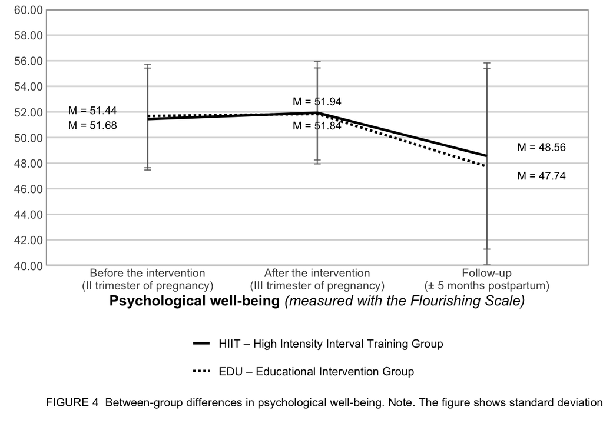

```r
# Add small nudges to labels
fs_sum <- fs_sum %>%
  mutate(label = sprintf("M = %.2f", mean)) %>%
  mutate(
    label_y = case_when(
      group == "HIIT" & grepl("^After", time) ~ 0.9,
      group == "EDU"  & grepl("^After", time) ~ -0.9,
      group == "HIIT" ~ 0.7,
      group == "EDU"  ~ -0.7
    ),
    label_x = case_when(
      grepl("^Before", time) ~ -0.18,
      grepl("^After",  time) ~  0.00,
      grepl("^Follow", time) ~  0.18
    ),
    label_hjust = case_when(
      grepl("^Before", time) ~ 1,
      grepl("^After",  time) ~ 0.5,
      grepl("^Follow", time) ~ 0
    )
  )

# Build the original plot
fig4 <- ggplot(fs_sum, aes(x = time, y = mean, group = group, linetype = group)) +

  # SD error bars: grey + SOLID, not affected by group linetype
  geom_errorbar(
    aes(ymin = mean - sd, ymax = mean + sd),
    width = 0.04,
    linewidth = 0.50,
    colour = "grey40",
    alpha = 0.75,
    linetype = "solid"
  ) +

  # Mean lines
  geom_line(linewidth = 1.0, colour = "black") +

  # Mean labels (custom x shift and vertical shift)
  geom_text(
    aes(
      label = label,
      y = mean + label_y,
      x = as.numeric(time) + label_x,
      hjust = label_hjust
    ),
    size = 3.2
  ) +

  scale_linetype_manual(
    values = c("HIIT" = "solid", "EDU" = "11"),
    labels = c("HIIT" = "HIIT – High Intensity Interval Training Group",
               "EDU"  = "EDU – Educational Intervention Group")
  ) +

  scale_y_continuous(
    limits = c(40, 60),
    breaks = seq(40, 60, 2),
    labels = function(x) sprintf("%.2f", x),
    expand = c(0, 0)
  ) +

  labs(
    caption = paste("FIGURE 4  Between-group differences in psychological well-being. Note. The figure shows standard deviation (SD) bars."),
    x = expression(bold("Psychological well-being") * " " * italic("(measured with the Flourishing Scale)")),
    y = NULL,
    linetype = NULL
  ) +

  theme_bw(base_size = 12) +
  theme(
    legend.position = "bottom",
    legend.box = "vertical",
    plot.caption = element_text(hjust = 0, margin = margin(t = 8)),
    plot.margin = margin(t = 8, r = 12, b = 18, l = 12),
    axis.ticks = element_blank(),
    panel.grid.minor = element_blank(),
    panel.grid.major.y = element_line(colour = "grey85", linewidth = 0.6),
    panel.grid.major.x = element_blank(),   # mostly horizontal gridlines like the original
    panel.border = element_rect(colour = "grey60", linewidth = 0.8)
    ) +
  guides(
  linetype = guide_legend(nrow = 2, byrow = TRUE)
  )

fig4
```

### Improved Figure 4

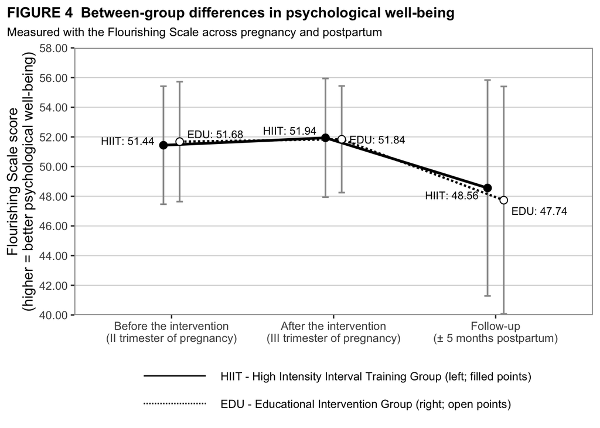

```r
# Dodge to seperate HIIT and EDU so SD bars don't overlap
pd <- position_dodge(width = 0.20)

# Make labels group specific
fs_sum <- fs_sum %>%
  mutate(
    label = paste0(group, ": ", sprintf("%.2f", mean)),

    # Baseline: put EDU above HIIT
    label_y = case_when(
      grepl("^Before", time) & group == "HIIT" ~ 0.3,
      grepl("^Before", time) & group == "EDU"  ~ 0.5,

      # keep the rest
      group == "HIIT" & grepl("^After", time)  ~ 0.5,
      group == "EDU"  & grepl("^After", time)  ~ 0.0,
      group == "HIIT" ~ -0.5,
      group == "EDU"  ~ -0.7
    )
  )

# Build the improved plot with dodged SD, points and lines and better group coding in legend
fig4_imp <- ggplot(fs_sum, aes(x = time, y = mean, group = group, linetype = group)) +
  geom_errorbar(
    aes(ymin = mean - sd, ymax = mean + sd),
    width = 0.08,
    linewidth = 0.65,
    colour = "grey60",
    linetype = "solid",
    position = pd
  ) +
  geom_line(aes(linewidth = group), colour = "black", position = pd) +
  scale_linewidth_manual(values = c("HIIT" = 1.05, "EDU" = 0.9), guide = "none") +

  # For points
  geom_point(
  aes(fill = group),
  position = pd,
  size = 2.6,
  shape = 21,        # allows fill + outline
  colour = "black",
  stroke = 0.6
  )+
  scale_fill_manual(
  values = c("HIIT" = "black", "EDU" = "white"),
  guide = "none"   # we’ll control the legend manually below
  )+

  # Make group postions clearer
  geom_text(
  data = fs_sum %>% filter(group == "HIIT"),
  aes(x = time, y = mean + label_y, label = label),
  nudge_x = -0.27,
  size = 3.2
  ) +

  geom_text(
  data = fs_sum %>% filter(group == "EDU"),
  aes(x = time, y = mean + label_y, label = label),
  nudge_x = 0.27,
  size = 3.2
  )+


  scale_linetype_manual(
  values = c("HIIT" = "solid", "EDU" = "11"),
  breaks = c("HIIT", "EDU"),
  labels = c(
    "HIIT - High Intensity Interval Training Group (left; filled points)",
    "EDU - Educational Intervention Group (right; open points)")
  ) +

  # Narrower y axis
  scale_y_continuous(
    limits = c(40, 58),
    breaks = seq(40, 58, 2),
    labels = \(x) sprintf("%.2f", x),
    expand = expansion(mult = c(0, 0))
  ) +

  # Labs similar to Figure 5
  labs(
  title = "FIGURE 4  Between-group differences in psychological well-being",
  subtitle = "Measured with the Flourishing Scale across pregnancy and postpartum",
  x = NULL,
  y = "Flourishing Scale score\n(higher = better psychological well-being)",
  linetype = NULL
  )+

  # Make theme match figure 5
  theme_bw(base_size = 12) +
  theme(
    plot.title = element_text(face = "bold", size = 12, hjust = 0),
    plot.subtitle = element_text(size = 10, hjust = 0, margin = margin(b = 8)),
    plot.title.position = "plot",
    panel.grid.major.y = element_line(linewidth = 0.4, colour = "grey85"),
    panel.grid.major.x = element_blank(),
    panel.grid.minor = element_blank(),
    panel.border = element_rect(colour = "grey60", linewidth = 0.8),
    axis.title.x = element_text(face = "bold", margin = margin(t = 8)),
    legend.position = "bottom",
    legend.key.width = unit(2.3, "cm"),
    legend.spacing.x = unit(0.6, "cm")
  ) +
  guides(
  linetype = guide_legend(
    nrow = 2,
    byrow = TRUE,
    override.aes = list(
      shape = 21,
      fill  = c("black", "white"),
      colour = "black",
      size = 3)
  )
)

fig4_imp
```

### Explanation of Figure 4 Improvements

The new graph improves readability by dodging the two groups slightly. By doing this, it prevents the standard deviation error bars from overlapping, making interpretation easier. We also made the group identity clearer by creating filled and open points (HIIT-filled points, EDU-open points). The mean labels are made into clearer group labels and are moved to avoid collisions. The y-axis range was made slightly narrower to highlight the differences between the lines better. The legend is simpler and has longer line indicators (solid vs dotted) that makes the distinction between the groups visibly apparent.

### Figure 5

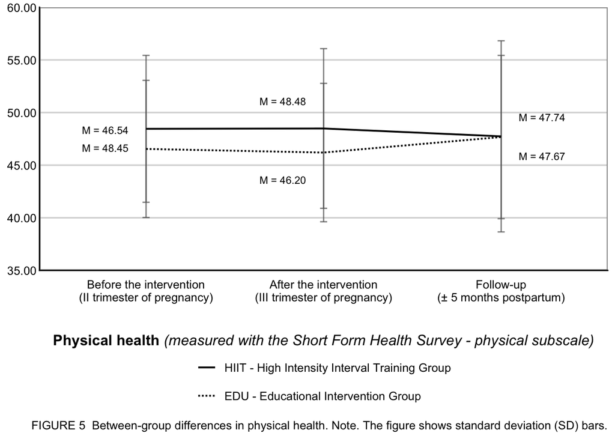

```r
# Write your code for reproducing, and then improving Figure 5. Present both figures together. Under the figures, explain how you've improved Figure 5 and why you consider this an improvement.

# Select relevant variables and define intervention groups
fig5_by_group <- data_raw %>%
  mutate(group = case_when(
      intervention_group == 1 ~ "HIIT",
      intervention_group == 2 ~ "EDU",
      TRUE ~ NA_character_),
    group = factor(group, levels = c("HIIT", "EDU"))) %>%
  transmute(group,
    pre_pcs = as.numeric(pre_sf_12_pcs_physicalhealthscale),
    post_pcs = as.numeric(post_sf12_pcs),
    postnatal_pcs = as.numeric(postnatal_sf_12_pcs)) %>%
  filter(!is.na(group)) %>%
  filter(complete.cases(pre_pcs, post_pcs, postnatal_pcs))

# Reshape data to long format to plot at the different time points
fig5_long <- fig5_by_group %>%
  pivot_longer(cols = c(pre_pcs, post_pcs, postnatal_pcs),
    names_to = "time",
    values_to = "pcs") %>%
  mutate(time = factor(time,
    levels = c("pre_pcs", "post_pcs", "postnatal_pcs"),
    labels = c("Before the intervention\n(II trimester of pregnancy)",
               "After the intervention\n(III trimester of pregnancy)",
               "Follow-up\n(± 5 months postpartum)"))
  )

# Calculate mean and standard deviation for each group and time point
mean_sd <- fig5_long %>%
  group_by(group, time) %>%
  summarise(mean = mean(pcs), sd = sd(pcs), .groups = "drop")

# Adjust the label positions to match the original figure
mean_sd_labs <- mean_sd %>%
  mutate(time_num = as.numeric(time),
    x_lab = case_when(
      time_num %in% c(1, 2) ~ time_num - 0.23, # to the left of SD line
      time_num == 3 ~ time_num + 0.23), # to the right of SD line
    y_shift = case_when(time_num == 2 ~ 2.6, TRUE ~ 1.8),
    # Default label placement: HIIT above, EDU below
    y_lab_default = mean + ifelse(group == "HIIT", y_shift, -y_shift),
    # Before intervention: swap label positions to replicate the original graph
    y_lab = ifelse(
      time_num == 1,
      mean + ifelse(group == "HIIT", -y_shift, y_shift),
      y_lab_default),
    label = sprintf("M = %.2f", mean)
  )

# Create Figure 5 to match the style and look of the original
fig5_plot <- ggplot(mean_sd,
                    aes(x = time, y = mean, group = group, linetype = group)) +
  geom_errorbar(aes(ymin = mean - sd, ymax = mean + sd),
    width = 0.04,
    colour = "grey40",
    linewidth = 0.50,
    alpha = 0.75,
    linetype = "solid") +
  geom_line(colour = "black", linewidth = 0.7) +
  geom_text(data = mean_sd_labs, aes(x = x_lab, y = y_lab, label = label), size = 3) +
  scale_linetype_manual(values = c("HIIT" = "solid", "EDU" = "11"),
    labels = c("HIIT - High Intensity Interval Training Group",
               "EDU - Educational Intervention Group")) +
  scale_y_continuous(limits = c(35, 60),
    breaks = c(35, 40, 45, 50, 55, 60),
    labels = function(x) sprintf("%.2f", x),
    expand = c(0, 0)) +
  labs(x = NULL, y = NULL,
    linetype = expression( bold("Physical health") * " " * italic("(measured with the Short Form Health Survey - physical subscale)")),
    caption = "FIGURE 5  Between-group differences in physical health. Note. The figure shows standard deviation (SD) bars.") +
  theme_classic(base_size = 12) +
  theme(
    legend.position = "bottom",
    legend.box = "vertical",
    panel.border = element_rect(colour = "grey60", linewidth = 0.8),
    axis.ticks = element_blank(),
    axis.text.x = element_text(margin = margin(t = 8)),
    panel.grid.major.y = element_line(colour = "grey85", linewidth = 0.6),
    legend.title = element_text(margin = margin(b = 6)),
    legend.box.margin = margin(t = 6)) +
  guides(linetype = guide_legend(
  title.position = "top",
  title.hjust = 0.5,
  nrow = 2, byrow = TRUE)
  )

fig5_plot
```

### Improved Figure 5

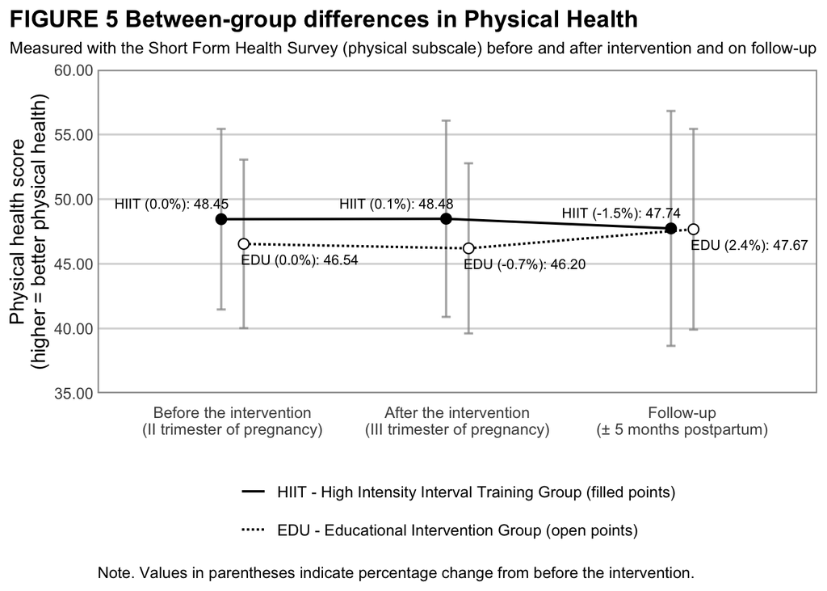

```r
# dodge so SD bars don't overlap
pd_5 <- position_dodge(width = 0.20)

# Add percentage changes
mean_sd_imp <- mean_sd %>%
  group_by(group) %>%
  mutate(baseline_mean = mean[as.numeric(time) == 1],
         pct_change = 100 * (mean - baseline_mean) / baseline_mean) %>%
  ungroup()

# Rebuild label table with new label text
mean_sd_labs_imp <- mean_sd_imp %>%
  mutate(time_num = as.numeric(time),
    # horizontal separation for clarity
    x_lab = time_num + if_else(group == "HIIT", -0.27, 0.30),
    # vertical separation
    y_lab = mean + if_else(group == "HIIT", 1.2, -1.2),
    # Label text
    label = sprintf("%s (%.1f%%): %.2f", group, pct_change, mean))

# Improved plot: better title and legend style and percentage change
fig5_improved <- ggplot(mean_sd_imp,
  aes(x = time, y = mean, group = group, linetype = group)) +
  geom_errorbar(aes(ymin = mean - sd, ymax = mean + sd),
    width = 0.08,
    colour = "grey60",
    linewidth = 0.65,
    alpha = 0.75,
    linetype = "solid",
    position = pd_5) +
  geom_line(colour = "black", linewidth = 0.7, position = pd_5) +
  geom_point(aes(fill = group),
    position = pd_5,
    size = 2.6,
    shape = 21,
    colour = "black",
    stroke = 0.6) +
  scale_fill_manual(values = c("HIIT" = "black", "EDU" = "white"), guide = "none") +
  geom_text(data = mean_sd_labs_imp, aes(x = x_lab, y = y_lab, label = label),
            size = 3) +
  # Linetypes and legend text
  scale_linetype_manual(values = c("HIIT" = "solid", "EDU" = "11"),
    breaks = c("HIIT", "EDU"),
    labels = c("HIIT - High Intensity Interval Training Group (filled points)",
      "EDU - Educational Intervention Group (open points)")) +
  scale_y_continuous(limits = c(35, 60),
    breaks = c(35, 40, 45, 50, 55, 60),
    labels = function(x) sprintf("%.2f", x),
    expand = c(0, 0)) +
  labs(title = "FIGURE 5 Between-group differences in Physical Health",
    subtitle = "Measured with the Short Form Health Survey (physical subscale) before and after intervention and on follow-up",
    x = NULL,
    y = "Physical health score\n(higher = better physical health)",
    linetype = NULL,
    caption = "Note. Values in parentheses indicate percentage change from before the intervention.") +
  theme_bw(base_size = 12) +
  theme(
    plot.title = element_text(face = "bold", hjust = 0),
    plot.subtitle = element_text(size = 10, hjust = 0, margin = margin(b = 8)),
    plot.title.position = "plot",
    legend.position = "bottom",
    legend.box = "vertical",
    panel.border = element_rect(colour = "grey60", linewidth = 0.8),
    axis.ticks = element_blank(),
    axis.text.x = element_text(margin = margin(t = 8)),
    panel.grid.major.y = element_line(colour = "grey85", linewidth = 0.6),
    panel.grid.major.x = element_blank(),
    panel.grid.minor = element_blank(),
    legend.title = element_text(margin = margin(b = 6)),
    legend.box.margin = margin(t = 6),
    plot.caption = element_text(hjust = 0, margin = margin(t = 8))) +
  # Show points in the legend
  guides(linetype = guide_legend(title.position = "top",
                                 title.hjust = 0.5,
                                 nrow = 2,
                                 byrow = TRUE,
                                 override.aes = list(
                                   shape = 21,
                                   fill = c("black", "white"),
                                   colour = "black",
                                   size = 3))
  )


fig5_improved
```

### Explanation of Figure 5 Improvements

The new figure improves the interpretability of the results because it shows the differences between groups more clearly. Manually separating the text labels and having filled and unfilled points makes it easier to distinguish between the two groups. Separating the SD bars also makes explicit which SD bar belongs to which group. The clear title subtitle and y axis label also add context to the figure and specify exactly what is the outcome being compared and for what timeline. We added the percentage change from baseline in parenthesis to give context to the paper’s conclusion that physical health remained relatively unchanged in both groups following the intervention.

## Task 2: FAIR data principles

The dataset meets several aspects of the FAIR data principles. It is publicly available in a recognised repository (Mendeley Data) and has been assigned a persistent DOI, so it can be easily found and cited. The data has a description, a clear title and authors, and has been assigned to categories which add to its findability. However, there is limited metadata, particularly because there is no data dictionary that explains the variables. The dataset could therefore include variable-level descriptions on each column, with units and coding.

In terms of accessibility, the dataset is openly accessible via a free and universally used protocol (https) and has no restrictions. Since the data is anonymised, an authentication procedure is not needed. Additionally, since it has a DOI, the metadata would remain accessible even if the data were removed. However, a description of how to access the data, given in Excel (proprietary format), would improve accessibility.

Looking at interoperability, although the data is presented in a standard table format, it is given as an Excel file, which could limit its compatibility in some workflows. Additionally, variable names are unclear and not matched to standard vocabularies (e.g., for depression scores). By using a non-proprietary format (e.g., csv) and standardised terminology it would become easier to integrate into other datasets.

The reusability of the dataset is strengthened by a clear licence, a brief description and linked publications. However, there is no documentation or instructions on how the data can be used. Including a codebook that describes each attribute of the data, or code examples that show how the data was processed and analysed in the publications, would improve reusability.

Overall, while the data is open and easy to access, its FAIR-ness could be strengthened by using standardised variable names, variable-level metadata, and non-proprietary formats.

## Task 3: Reproducibility brief

Your study has some good aspects that make it reproducible. You have made your dataset publicly available in a trusted repository and linked it to published articles that use it. This means others can find and access the data to reproduce your work. You also describe the intervention, outcomes, and study design in detail, which makes your work easier to understand and gives a good idea of your workflow.

However, your workflow still needs to be more transparent. Although the results can be understood from your descriptions, it would be difficult for someone to follow the exact steps you took in your analysis and get the same results. You could add a link to the code that you used to clean and analyse the data (for example, in a GitHub repository). In this repo, put any scripts you used, e.g., preprocessing, generating figures, and statistical analysis.

Second, I would recommend documenting your variables more clearly. An option would be to add a README or a codebook that answers questions like: how were variables calculated, how did you handle missing data, which participants were excluded? After this, you can add a short file that gives instructions on how to run your code, making it easier to follow your workflow.

It is good that you specify the software environments and packages you used for the analysis and include the specific versions and parameters. However, instead of simply adding figures and brief notes as linked supplementary material, you could go into more detail on how you used each package (e.g., syntax for ITT) in a separate ‘instructions’ document and add which packages are required as an appendix.

These changes would make it easier for others to follow your pipeline, perform the same analysis steps, and get the same results.